# **Project Brief: The "*Sugar Trap*" Market Gap Analysis**

### What I'm Building

I am working as a data analyst for Helix CPG Partners, a strategic food and beverage consultancy. The client is a global snack manufacturer preparing to launch a new healthy snacking product line.

The core business problem is that the client believes the snack market is oversaturated with high-sugar, high-fat products, but they need data to prove it, and more importantly, to identify exactly where the gaps are.

## **Story 1: Data Ingestion & "The Clean Up"**

Cleaning the dataset that removes products with erroneous nutritional information, so that my analysis is not skewed by bad data entry.

```python
# libraries and modules needed for the project
import pandas as pd
import numpy as np
import os
import matplotlib.pyplot as plt
import seaborn as sns
import re
```

```python
#downloading the Open Food Facts dataset
!wget https://static.openfoodfacts.org/data/en.openfoodfacts.org.products.csv.gz
```

[output not shown]

```python
os.listdir()
```

```
['.config',
 'cleaned_food_data.csv',
 'en.openfoodfacts.org.products.csv.gz.1',
 'en.openfoodfacts.org.products.csv.gz.3',
 'AmaliTech_Capstone_Project.pdf',
 'AmaliTech_Capstone_Project.ipynb',
 'en.openfoodfacts.org.products.csv.gz',
 '.ipynb_checkpoints',
 'en.openfoodfacts.org.products.csv.gz.2',
 'sample_data']
```

```python
# reading the csv file and correctly resetting the index outside the function call
food_data = pd.read_csv("en.openfoodfacts.org.products.csv.gz", header=0, sep='\t', nrows=500000, low_memory=False)
```

```python
food_data
```

|  | code | url | creator | created_t | created_datetime | last_modified_t | last_modified_datetime | last_modified_by | last_updated_t | last_updated_datetime | ... | choline_100g | phylloquinone_100g | beta-glucan_100g | inositol_100g | carnitine_100g | sulphate_100g | nitrate_100g | acidity_100g | carbohydrates-total_100g | water_100g |
| --- | --- | --- | --- | --- | --- | --- | --- | --- | --- | --- | --- | --- | --- | --- | --- | --- | --- | --- | --- | --- | --- |
| 0 | 54 | http://world-en.openfoodfacts.org/product/0000... | kiliweb | 1582569031 | 2020-02-24T18:30:31Z | 1733085204 | 2024-12-01T20:33:24Z | NaN | 1.740205e+09 | 2025-02-22T06:23:42Z | ... | NaN | NaN | NaN | NaN | NaN | NaN | NaN | NaN | NaN | NaN |
| 1 | 63 | http://world-en.openfoodfacts.org/product/0000... | kiliweb | 1673620307 | 2023-01-13T14:31:47Z | 1750061386 | 2025-06-16T08:09:46Z | bodysupport | 1.750061e+09 | 2025-06-16T08:09:46Z | ... | NaN | NaN | NaN | NaN | NaN | NaN | NaN | NaN | NaN | NaN |
| 2 | 114 | http://world-en.openfoodfacts.org/product/0000... | kiliweb | 1580066482 | 2020-01-26T19:21:22Z | 1751035658 | 2025-06-27T14:47:38Z | teolemon | 1.751036e+09 | 2025-06-27T14:47:38Z | ... | NaN | NaN | NaN | NaN | NaN | NaN | NaN | NaN | NaN | NaN |
| 3 | 431 | http://world-en.openfoodfacts.org/product/0000... | kiliweb | 1714301712 | 2024-04-28T10:55:12Z | 1714301721 | 2024-04-28T10:55:21Z | kiliweb | 1.714302e+09 | 2024-04-28T10:55:21Z | ... | NaN | NaN | NaN | NaN | NaN | NaN | NaN | NaN | NaN | NaN |
| 4 | 105 | http://world-en.openfoodfacts.org/product/0000... | kiliweb | 1572117743 | 2019-10-26T19:22:23Z | 1738073570 | 2025-01-28T14:12:50Z | NaN | 1.743653e+09 | 2025-04-03T04:11:36Z | ... | NaN | NaN | NaN | NaN | NaN | NaN | NaN | NaN | NaN | NaN |
| ... | ... | ... | ... | ... | ... | ... | ... | ... | ... | ... | ... | ... | ... | ... | ... | ... | ... | ... | ... | ... | ... |
| 499995 | 88573220018 | http://world-en.openfoodfacts.org/product/0088... | kiliweb | 1658369691 | 2022-07-21T02:14:51Z | 1658369693 | 2022-07-21T02:14:53Z | kiliweb | 1.707865e+09 | 2024-02-13T22:59:03Z | ... | NaN | NaN | NaN | NaN | NaN | NaN | NaN | NaN | NaN | NaN |
| 499996 | 88573331004 | http://world-en.openfoodfacts.org/product/0088... | swipe-studio | 1608767681 | 2020-12-23T23:54:41Z | 1686695635 | 2023-06-13T22:33:55Z | garyw | 1.771285e+09 | 2026-02-16T23:37:46Z | ... | NaN | NaN | NaN | NaN | NaN | NaN | NaN | NaN | NaN | NaN |
| 499997 | 88573402421 | http://world-en.openfoodfacts.org/product/0088... | waistline-app | 1750609917 | 2025-06-22T16:31:57Z | 1750609922 | 2025-06-22T16:32:02Z | waistline-app | 1.750610e+09 | 2025-06-22T16:32:02Z | ... | NaN | NaN | NaN | NaN | NaN | NaN | NaN | NaN | NaN | NaN |
| 499998 | 88573444445 | http://world-en.openfoodfacts.org/product/0088... | foodless | 1643224572 | 2022-01-26T19:16:12Z | 1656518574 | 2022-06-29T16:02:54Z | kiliweb | 1.771284e+09 | 2026-02-16T23:15:53Z | ... | NaN | NaN | NaN | NaN | NaN | NaN | NaN | NaN | NaN | NaN |
| 499999 | 88573800012 | http://world-en.openfoodfacts.org/product/0088... | kiliweb | 1626831085 | 2021-07-21T01:31:25Z | 1734312571 | 2024-12-16T01:29:31Z | waistline-app | 1.738803e+09 | 2025-02-06T00:44:14Z | ... | NaN | NaN | NaN | NaN | NaN | NaN | NaN | NaN | NaN | NaN |

500000 rows × 210 columns

```python
# displaying all the columns in the dataset to be able to select the needed categories
food_data.columns
```

```
Index(['code', 'url', 'creator', 'created_t', 'created_datetime',
       'last_modified_t', 'last_modified_datetime', 'last_modified_by',
       'last_updated_t', 'last_updated_datetime',
       ...
       'choline_100g', 'phylloquinone_100g', 'beta-glucan_100g',
       'inositol_100g', 'carnitine_100g', 'sulphate_100g', 'nitrate_100g',
       'acidity_100g', 'carbohydrates-total_100g', 'water_100g'],
      dtype='object', length=210)
```

```python
for column in food_data.columns:
  print(column)
```

```
code
url
creator
created_t
created_datetime
last_modified_t
last_modified_datetime
last_modified_by
last_updated_t
last_updated_datetime
product_name
abbreviated_product_name
generic_name
quantity
packaging
packaging_tags
packaging_en
packaging_text
brands
brands_tags
brands_en
categories
categories_tags
categories_en
origins
origins_tags
origins_en
manufacturing_places
manufacturing_places_tags
labels
labels_tags
labels_en
emb_codes
emb_codes_tags
first_packaging_code_geo
cities
cities_tags
purchase_places
stores
countries
```

[output cut: 155 more lines]

```
cocoa_100g
chlorophyl_100g
carbon-footprint_100g
glycemic-index_100g
water-hardness_100g
choline_100g
phylloquinone_100g
beta-glucan_100g
inositol_100g
carnitine_100g
sulphate_100g
nitrate_100g
acidity_100g
carbohydrates-total_100g
water_100g
```

```python
columns = [
    'product_name',
    'brands',
    'categories_en',
    'categories_tags',
    'main_category_en',
    'pnns_groups_1',
    'pnns_groups_2',
    'countries_en',
    'sugars_100g',
    'fat_100g',
    'saturated-fat_100g',
    'proteins_100g',
    'fiber_100g',
    'carbohydrates_100g',
    'salt_100g',
    'energy-kcal_100g',
    'nutriscore_score',
    'nutriscore_grade',
    'nova_group',
    'unique_scans_n',
    'ingredients_text',
]
```

```python
food_data = food_data[columns]
food_data
```

|  | product_name | brands | categories_en | categories_tags | main_category_en | pnns_groups_1 | pnns_groups_2 | countries_en | sugars_100g | fat_100g | ... | proteins_100g | fiber_100g | carbohydrates_100g | salt_100g | energy-kcal_100g | nutriscore_score | nutriscore_grade | nova_group | unique_scans_n | ingredients_text |
| --- | --- | --- | --- | --- | --- | --- | --- | --- | --- | --- | --- | --- | --- | --- | --- | --- | --- | --- | --- | --- | --- |
| 0 | Limonade artisanale a la rose | NaN | NaN | NaN | NaN | unknown | unknown | France | NaN | NaN | ... | NaN | NaN | NaN | NaN | NaN | NaN | unknown | NaN | NaN | NaN |
| 1 | M&amp;M white | Fitpiggy | NaN | NaN | NaN | unknown | unknown | France | NaN | NaN | ... | NaN | NaN | NaN | NaN | NaN | NaN | unknown | NaN | 1.0 | Weizenmehl, Rapsöl, Speisesalz, 1,7% Meersalz,... |
| 2 | Chocolate n3 | Jeff de Bruges | NaN | NaN | NaN | unknown | unknown | France | NaN | NaN | ... | NaN | NaN | NaN | NaN | NaN | NaN | unknown | NaN | 1.0 | NaN |
| 3 | Pâte de fruits | NaN | NaN | NaN | NaN | unknown | unknown | France | NaN | NaN | ... | NaN | NaN | NaN | NaN | NaN | NaN | unknown | NaN | NaN | NaN |
| 4 | Paleta gran reserva - Sierra nevada- | AdvoCare | Beverages and beverages preparations,Beverages | en:beverages-and-beverages-preparations,en:bev... | Beverages | Beverages | Artificially sweetened beverages | Germany,Spain | NaN | NaN | ... | NaN | NaN | NaN | NaN | NaN | NaN | unknown | 4.0 | 1.0 | Thiamin, Biotin, Chromium, Garcinia cambogia f... |
| ... | ... | ... | ... | ... | ... | ... | ... | ... | ... | ... | ... | ... | ... | ... | ... | ... | ... | ... | ... | ... | ... |
| 499995 | Seltzer | NaN | NaN | NaN | NaN | unknown | unknown | United States | NaN | NaN | ... | NaN | NaN | NaN | NaN | NaN | NaN | unknown | NaN | NaN | NaN |
| 499996 | Beer | Shiner | NaN | NaN | NaN | unknown | unknown | United States | NaN | NaN | ... | NaN | NaN | NaN | NaN | NaN | NaN | unknown | NaN | 1.0 | NaN |
| 499997 | Light Blonde | Shiner | NaN | NaN | NaN | unknown | unknown | United States | NaN | NaN | ... | NaN | NaN | NaN | NaN | NaN | NaN | unknown | NaN | NaN | NaN |
| 499998 | Shiner Bock | NaN | NaN | NaN | NaN | unknown | unknown | United States | NaN | NaN | ... | NaN | NaN | NaN | NaN | NaN | NaN | unknown | NaN | 1.0 | NaN |
| 499999 | Holiday Cheer | Shiner | NaN | NaN | NaN | unknown | unknown | United States | NaN | NaN | ... | NaN | NaN | NaN | NaN | NaN | NaN | unknown | NaN | 1.0 | NaN |

500000 rows × 21 columns

```python
# removing rows with missing values
food_data = food_data.dropna(subset=[
    'product_name',
    'sugars_100g',
    'fat_100g',
    'saturated-fat_100g',
    'proteins_100g',
    'fiber_100g',
    'carbohydrates_100g',
    'salt_100g',
    'energy-kcal_100g',
])

#removing rows where product_name is empty
food_data = food_data[food_data['product_name'].str.strip() != ""]
```

```python
#keeping only nutritional values (0–100g per 100g)
food_data = food_data[
    (food_data['sugars_100g'].between(0, 100)) &
    (food_data['proteins_100g'].between(0, 100)) &
    (food_data['fat_100g'].between(0, 100)) &
    (food_data['fiber_100g'].between(0, 100)) &
    (food_data['carbohydrates_100g'].between(0, 100)) &
    (food_data['salt_100g'].between(0, 100)) &
    (food_data['saturated-fat_100g'].between(0, 100))
]
```

```python
food_data
```

|  | product_name | brands | categories_en | categories_tags | main_category_en | pnns_groups_1 | pnns_groups_2 | countries_en | sugars_100g | fat_100g | ... | proteins_100g | fiber_100g | carbohydrates_100g | salt_100g | energy-kcal_100g | nutriscore_score | nutriscore_grade | nova_group | unique_scans_n | ingredients_text |
| --- | --- | --- | --- | --- | --- | --- | --- | --- | --- | --- | --- | --- | --- | --- | --- | --- | --- | --- | --- | --- | --- |
| 695 | Keto & GF Granola | Cook & Baker Bali | NaN | NaN | NaN | unknown | unknown | Germany | 3.225806 | 54.838710 | ... | 19.677419 | 9.677419 | 19.354839 | 0.524194 | 580.645161 | NaN | unknown | NaN | NaN | NaN |
| 843 | pasta | Grappa | Beverages and beverages preparations,Beverages | en:beverages-and-beverages-preparations,en:bev... | Beverages | unknown | unknown | France,Germany | 1.900000 | 6.400000 | ... | 6.700000 | 0.800000 | 20.000000 | 0.000900 | 166.000000 | 5.0 | c | NaN | 4.0 | NaN |
| 851 | Dunnes Stores Irish Beef & Pork Quarter Pounders | Dunnes Stores | NaN | NaN | NaN | unknown | unknown | Ireland | 0.521739 | 11.304348 | ... | 15.652174 | 0.782609 | 2.521739 | 0.530435 | 176.656414 | NaN | unknown | NaN | NaN | NaN |
| 862 | Protein Plenty Tamarind Almonds | Itsu | NaN | NaN | NaN | unknown | unknown | United Kingdom | 4.750000 | 50.000000 | ... | 27.500000 | 11.000000 | 7.500000 | 2.018750 | 617.500000 | NaN | unknown | NaN | 1.0 | NaN |
| 868 | Eirn original curry Sauce | Eirn | Plant-based foods and beverages,Plant-based fo... | en:plant-based-foods-and-beverages,en:plant-ba... | Sauce-powder | unknown | unknown | Ireland | 29.600000 | 18.000000 | ... | 5.200000 | 1.200000 | 57.200000 | 4.750000 | 411.000000 | NaN | not-applicable | 4.0 | 1.0 | Wheat Flour Sugar Vegetable Fat D Curry Powder... |
| ... | ... | ... | ... | ... | ... | ... | ... | ... | ... | ... | ... | ... | ... | ... | ... | ... | ... | ... | ... | ... | ... |
| 499955 | Garlic Original | Foster's Pickled Products | NaN | NaN | NaN | unknown | unknown | World | 3.571429 | 0.000000 | ... | 3.571429 | 3.571429 | 21.428571 | 0.848214 | 107.142857 | NaN | unknown | NaN | NaN | NaN |
| 499965 | Asparagus Original | Foster's Pickled Products | NaN | NaN | NaN | unknown | unknown | Canada,World | 3.333333 | 0.000000 | ... | 3.333333 | 0.000000 | 3.333333 | 1.575000 | 33.333333 | NaN | unknown | NaN | 1.0 | NaN |
| 499982 | Blackened Salmon With Couscous, Quinoa, & Veggies | Fusha | NaN | NaN | NaN | unknown | unknown | United States | 0.961538 | 5.128205 | ... | 8.012821 | 0.961538 | 9.615385 | 0.044071 | 115.384615 | NaN | unknown | NaN | NaN | NaN |
| 499986 | Blackened Chicken With Mac & Cheese | Marwan’s Street Grub | NaN | NaN | NaN | unknown | unknown | United States | 2.352941 | 3.823529 | ... | 9.117647 | 0.294118 | 15.882353 | 0.602941 | 138.235294 | NaN | unknown | NaN | NaN | NaN |
| 499989 | Swedish Meatballs | Marwan’s Kitchen - Street Grub | NaN | NaN | NaN | unknown | unknown | United States | 2.352941 | 11.176471 | ... | 6.176471 | 0.882353 | 14.411765 | 1.235294 | 185.294118 | NaN | unknown | NaN | NaN | NaN |

63423 rows × 21 columns

```python
food_data.describe()
```

|  | sugars_100g | fat_100g | saturated-fat_100g | proteins_100g | fiber_100g | carbohydrates_100g | salt_100g | energy-kcal_100g | nutriscore_score | nova_group | unique_scans_n |
| --- | --- | --- | --- | --- | --- | --- | --- | --- | --- | --- | --- |
| count | 63423.000000 | 63423.000000 | 63423.000000 | 63423.000000 | 63423.000000 | 63423.000000 | 63423.000000 | 63423.000000 | 34100.000000 | 32202.000000 | 28094.000000 |
| mean | 12.038820 | 11.635392 | 3.874285 | 8.678158 | 2.907247 | 33.915101 | 1.207861 | 290.070868 | 9.094839 | 3.550960 | 3.205916 |
| std | 17.341024 | 14.970220 | 6.351785 | 9.516378 | 4.899798 | 27.300066 | 3.556145 | 1287.532688 | 9.606452 | 0.903754 | 6.534455 |
| min | 0.000000 | 0.000000 | 0.000000 | 0.000000 | 0.000000 | 0.000000 | 0.000000 | 0.000000 | -17.000000 | 1.000000 | 1.000000 |
| 25% | 1.176471 | 1.180000 | 0.000000 | 2.941178 | 0.000000 | 8.666667 | 0.131579 | 112.247294 | 2.000000 | 3.000000 | 1.000000 |
| 50% | 4.500000 | 5.300000 | 1.250000 | 6.670000 | 1.662500 | 27.000000 | 0.703125 | 265.000000 | 7.000000 | 4.000000 | 1.000000 |
| 75% | 14.290000 | 17.648529 | 5.000000 | 10.800000 | 3.571429 | 57.140000 | 1.300000 | 398.000000 | 16.000000 | 4.000000 | 3.000000 |
| max | 100.000000 | 100.000000 | 100.000000 | 100.000000 | 100.000000 | 100.000000 | 100.000000 | 286500.000000 | 51.000000 | 4.000000 | 351.000000 |

```python
food_data.info()
```

```
<class 'pandas.core.frame.DataFrame'>
Index: 63423 entries, 695 to 499989
Data columns (total 21 columns):
 #   Column              Non-Null Count  Dtype
---  ------              --------------  -----
 0   product_name        63423 non-null  object
 1   brands              49535 non-null  object
 2   categories_en       35977 non-null  object
 3   categories_tags     35977 non-null  object
 4   main_category_en    35977 non-null  object
 5   pnns_groups_1       63423 non-null  object
 6   pnns_groups_2       63423 non-null  object
 7   countries_en        63380 non-null  object
 8   sugars_100g         63423 non-null  float64
 9   fat_100g            63423 non-null  float64
 10  saturated-fat_100g  63423 non-null  float64
 11  proteins_100g       63423 non-null  float64
 12  fiber_100g          63423 non-null  float64
 13  carbohydrates_100g  63423 non-null  float64
 14  salt_100g           63423 non-null  float64
 15  energy-kcal_100g    63423 non-null  float64
 16  nutriscore_score    34100 non-null  float64
 17  nutriscore_grade    63423 non-null  object
 18  nova_group          32202 non-null  float64
 19  unique_scans_n      28094 non-null  float64
 20  ingredients_text    34471 non-null  object
dtypes: float64(11), object(10)
memory usage: 10.6+ MB
```

## **Story 2: The Category Wrangler**

Grouping products into readable high-level categories, so that I don't have to look at 10,000 unique, messy tags.

```python
#filliing the NaN values in the categories_en  with an empty string to avoid errors during string operations
food_data['categories_en'] = food_data['categories_en'].fillna('')
```

```python
#showing the different category tags
food_data['categories_tags'].unique()
```

```
array([nan, 'en:beverages-and-beverages-preparations,en:beverages',
       'en:plant-based-foods-and-beverages,en:plant-based-foods,en:condiments,en:spices,en:curry-powder,en:powder,en:sauce-powder',
       ..., 'es:salsa-de-tomate-enlatado',
       'en:plant-based-foods-and-beverages-plant-based-foods-condiments-spices-curry-curry-powder',
       'en:plant-based-foods-and-beverages,en:plant-based-foods,en:cereals-and-potatoes,en:cereals-and-their-products,en:meals,en:pasta-dishes,en:pastas,en:stuffed-pastas,en:ravioli,en:refrigerated-foods,en:meals-with-shellfish,en:refrigerated-meals,en:chinese-raviolis,en:japanese-ravioli,en:meals-w…
      dtype=object)
```

```python
# the categories function takes the category tags of a product and maps them to a simplified classification
def categories(category_tags):
    # converts the input to a lowercase string to ensure consistent keyword matching across the dataset
    tags = str(category_tags).lower()

    # snack sub categories
    if 'chocolate' in tags or 'chocolat' in tags:
        return 'Chocolate'

    elif any(tag in tags for tag in ['chips', 'crisps', 'popcorn', 'pretzel', 'crackers', 'tortilla', 'nachos']):
        return 'Chips & Crisps'

    elif any(tag in tags for tag in ['salty', 'salted', 'craquelins', 'appetizers']):
        return 'Salty Snacks'

    elif any(tag in tags for tag in ['cookie', 'biscuit', 'wafer', 'cake', 'muffin', 'pastry', 'madeleine', 'viennoiseries', 'doughnut', 'dessert', 'pie', 'sweet-snacks']):
        return 'Cookies & Cakes'

    elif any(tag in tags for tag in ['granola', 'protein-bar', 'energy-bar', 'cereal-bar', 'protein-shake', 'proteiques', 'supplement', 'whey', 'bars']):
        return 'Bars & Granola'

    elif any(tag in tags for tag in ['nut', 'seed', 'peanut', 'almond', 'cashew', 'walnut', 'pistachio', 'trail mix', 'arachide', 'trail-mix']):
        return 'Nuts & Seeds'

    elif any(tag in tags for tag in ['confectionery', 'bonbon', 'candy', 'caramel', 'fudge', 'marshmallow', 'licorice', 'confectioneries', 'candies', 'gummi-candies']):
        return 'Candies & Sweets'

    elif any(tag in tags for tag in ['beverage', 'drink', 'juice', 'water', 'coffee', 'tea', 'soda', 'cola']):
        return 'Beverages'

    elif any(tag in tags for tag in ['dairy', 'milk', 'cheese', 'yogurt', 'yaourt', 'pudding', 'skyr', 'mousse', 'ice-cream', 'dairies', 'creams']):
        return 'Dairy'

    elif any(tag in tags for tag in ['fruit', 'vegetable', 'plant-based', 'legume', 'compote', 'apricot', 'date', 'raisins', 'prugne']):
        return 'Fruits, Vegetables & Legumes'

    elif any(tag in tags for tag in ['grain', 'bread', 'pasta', 'rice', 'cereal', 'flour']):
        return 'Grains & Baked Goods'

    elif any(tag in tags for tag in ['meat', 'poultry', 'fish', 'seafood', 'beef', 'chicken', 'pork']):
        return 'Meat & Seafood'

    elif any(tag in tags for tag in ['meal', 'prepared', 'pizza', 'soup', 'stew', 'ravioli', 'burger', 'sandwich', 'burrito', 'tamales', 'mexican-dinner-mixes']):
        return 'Prepared Meals'

    elif any(tag in tags for tag in ['oil', 'fat', 'butter', 'margarine']):
        return 'Fats & Oils'

    elif any(tag in tags for tag in ['sauce', 'spice', 'condiment', 'ketchup', 'mustard', 'pesto', 'syrup', 'sweetener', 'honey', 'spreads', 'tapenade', 'salsa']):
        return 'Sauces & Spices'

    else:
        return 'Other Snacks'
```

```python
#applying the cleaned categorization logic using the renamed function
food_data['primary_category'] = food_data['categories_tags'].apply(categories)
```

```python
food_data['primary_category'].value_counts().sort_index()
```

| primary_category | count |
| --- | --- |
| Bars & Granola | 272 |
| Beverages | 13858 |
| Candies & Sweets | 11 |
| Chips & Crisps | 1789 |
| Chocolate | 1505 |
| Cookies & Cakes | 7133 |
| Dairy | 1468 |
| Fats & Oils | 53 |
| Fruits, Vegetables & Legumes | 95 |
| Grains & Baked Goods | 590 |
| Meat & Seafood | 2079 |
| Nuts & Seeds | 1770 |
| Other Snacks | 29482 |
| Prepared Meals | 878 |
| Salty Snacks | 662 |
| Sauces & Spices | 1778 |

**dtype:** int64

```python
food_data[['product_name', 'primary_category']].head(10)
```

|  | product_name | primary_category |
| --- | --- | --- |
| 695 | Keto & GF Granola | Other Snacks |
| 843 | pasta | Beverages |
| 851 | Dunnes Stores Irish Beef & Pork Quarter Pounders | Other Snacks |
| 862 | Protein Plenty Tamarind Almonds | Other Snacks |
| 868 | Eirn original curry Sauce | Beverages |
| 895 | Familjepack Schnitzel Frysta | Beverages |
| 932 | Crème oignon | Other Snacks |
| 958 | Coca cola | Beverages |
| 1004 | Tostadas | Beverages |
| 1019 | Omelette al gusto bacon | Other Snacks |

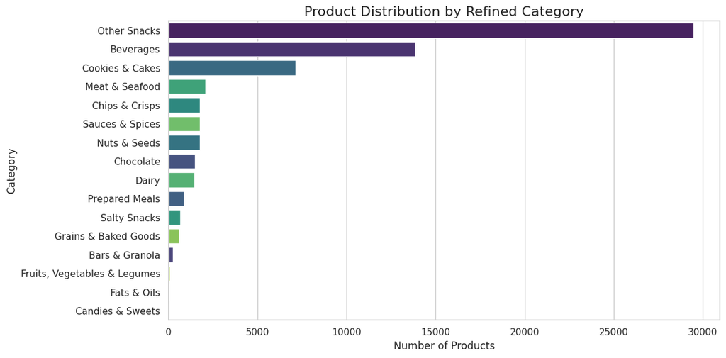

```python
#visualizing the distribution of the categories
plt.figure(figsize=(12, 6))
sns.countplot(
    data=food_data,
    y='primary_category',
    order=food_data['primary_category'].value_counts().index,
    hue='primary_category',
    palette='viridis',
    legend=False
)

plt.title('Product Distribution by Refined Category', fontsize=16)
plt.xlabel('Number of Products', fontsize=12)
plt.ylabel('Category', fontsize=12)
plt.tight_layout()
plt.show()
```

## **Story 3: The "Nutrient Matrix" Visualization**

Creating a scatter Plot comparing Sugar (X-axis) vs. Protein (Y-axis) for different categories, so that I can visually spot where the products are clustered.

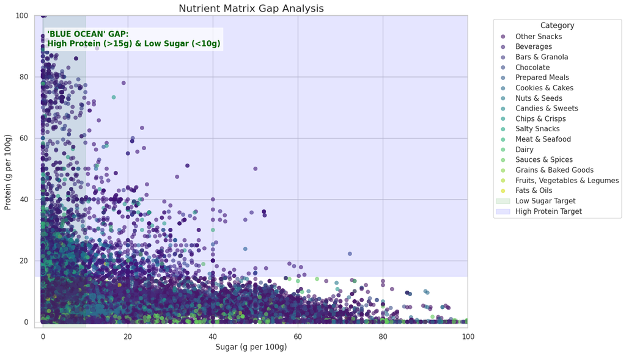

```python
# defining the target segments with lower-case variable names
low_sugar_threshold = 10
high_protein_threshold = 15

plt.figure(figsize=(14, 8))
sns.set_theme(style='whitegrid')

#creaating scatter plot
scatter = sns.scatterplot(
    data=food_data,
    x='sugars_100g',
    y='proteins_100g',
    hue='primary_category',
    alpha=0.6,
    edgecolor=None,
    palette='viridis'
)

#highlighting the empty quadrant (High Protein + Low Sugar)
plt.axvspan(0, low_sugar_threshold, color='green', alpha=0.1, label='Low Sugar Target')
plt.axhspan(high_protein_threshold, 100, color='blue', alpha=0.1, label='High Protein Target')

plt.text(1, 90, "'BLUE OCEAN' GAP:\nHigh Protein (>15g) & Low Sugar (<10g)",
         fontsize=12, color='darkgreen', fontweight='bold',
         bbox=dict(facecolor='white', alpha=0.7))

plt.title('Nutrient Matrix Gap Analysis', fontsize=16)
plt.xlabel('Sugar (g per 100g)', fontsize=12)
plt.ylabel('Protein (g per 100g)', fontsize=12)
plt.xlim(-2, 100)
plt.ylim(-2, 100)
plt.legend(title='Category', bbox_to_anchor=(1.05, 1), loc='upper left')
plt.tight_layout()
plt.show()
```

```python
#calculating the stats
total_products = food_data[(food_data['sugars_100g'] < 10) & (food_data['proteins_100g'] > 15)]

print(f"Total products found in the 'Blue Ocean' quadrant: {len(total_products)}")

print("\nTop categories currently occupying this space:")
display(total_products['primary_category'].value_counts())

print("\nSample products in the target gap:")
display(total_products[['product_name', 'brands', 'sugars_100g', 'proteins_100g']].head(10))
```

```
Total products found in the 'Blue Ocean' quadrant: 8190

Top categories currently occupying this space:
```

| primary_category | count |
| --- | --- |
| Other Snacks | 4751 |
| Meat & Seafood | 1153 |
| Dairy | 709 |
| Nuts & Seeds | 665 |
| Beverages | 399 |
| Bars & Granola | 144 |
| Salty Snacks | 117 |
| Cookies & Cakes | 65 |
| Grains & Baked Goods | 60 |
| Prepared Meals | 41 |
| Chips & Crisps | 32 |
| Chocolate | 32 |
| Sauces & Spices | 20 |
| Fats & Oils | 2 |

**dtype:** int64

```
Sample products in the target gap:
```

|  | product_name | brands | sugars_100g | proteins_100g |
| --- | --- | --- | --- | --- |
| 695 | Keto & GF Granola | Cook & Baker Bali | 3.225806 | 19.677419 |
| 851 | Dunnes Stores Irish Beef & Pork Quarter Pounders | Dunnes Stores | 0.521739 | 15.652174 |
| 862 | Protein Plenty Tamarind Almonds | Itsu | 4.750000 | 27.500000 |
| 1019 | Omelette al gusto bacon | Iberia | 1.600000 | 71.000000 |
| 1157 | Uncured Beef Hot Dogs | Good Chop | 0.000000 | 17.543860 |
| 1162 | Ribeye | Good Chop | 0.000000 | 18.518845 |
| 1201 | carte macdo | NaN | 9.000000 | 17.000000 |
| 1239 | Everything Nut Blend | nutri | 3.571429 | 17.857143 |
| 1550 | Lpm | NaN | 0.000000 | 25.000000 |
| 1571 | Tenders kfc | NaN | 0.500000 | 21.000000 |

```python
# creating a market summary table with average sugar and protein metrics
category_nutrient_summary = food_data.groupby('primary_category').agg({'sugars_100g': 'mean','proteins_100g': 'mean','product_name': 'count'}).rename(columns={'sugars_100g': 'Avg Sugar (g)','proteins_100g': 'Avg Protein (g)','product_name': 'Total Count'}).sort_values(by='Avg Protein (g)', ascending=False)

# calculating Saturation_Score and add it to the summary table
category_nutrient_summary['Saturation_Score'] = (
    category_nutrient_summary['Total Count'] / category_nutrient_summary['Total Count'].max() * 0.7 +
    category_nutrient_summary['Avg Sugar (g)'] / 100 * 0.3
)

# displaying the styled benchmark table with the new saturation score
category_nutrient_summary.style.background_gradient(cmap='RdYlGn_r', subset=['Avg Sugar (g)']).background_gradient(cmap='RdYlGn', subset=['Avg Protein (g)']).background_gradient(cmap='viridis_r', subset=['Saturation_Score'])
```

| primary_category | Avg Sugar (g) | Avg Protein (g) | Total Count | Saturation_Score |
| --- | --- | --- | --- | --- |
| Bars & Granola | 7.005308 | 41.598873 | 272 | 0.027474 |
| Meat & Seafood | 1.876502 | 17.266874 | 2079 | 0.054992 |
| Dairy | 3.226358 | 15.352797 | 1468 | 0.044534 |
| Nuts & Seeds | 6.036145 | 13.072552 | 1770 | 0.060134 |
| Other Snacks | 12.414710 | 9.385985 | 29482 | 0.737244 |
| Salty Snacks | 3.687060 | 8.516106 | 662 | 0.026779 |
| Grains & Baked Goods | 3.482467 | 8.054733 | 590 | 0.024456 |
| Beverages | 8.924167 | 7.113822 | 13858 | 0.355807 |
| Chips & Crisps | 7.372209 | 6.891125 | 1789 | 0.064593 |
| Chocolate | 39.110490 | 6.688538 | 1505 | 0.153065 |
| Prepared Meals | 3.748853 | 6.308909 | 878 | 0.032093 |
| Cookies & Cakes | 18.950485 | 5.520013 | 7133 | 0.226212 |
| Fruits, Vegetables & Legumes | 12.693547 | 4.404538 | 95 | 0.040336 |
| Fats & Oils | 3.837149 | 3.771124 | 53 | 0.012770 |
| Sauces & Spices | 20.125687 | 2.175027 | 1778 | 0.102593 |
| Candies & Sweets | 38.714407 | 1.948207 | 11 | 0.116404 |

The saturation score was introduced to quantify market opportunity by combining product count and average sugar content into a single metric. This helps in identifying categories that are less saturated and potentially have higher growth potential for new, healthier products. It gives a more holistic view beyond just individual nutrient levels, providing strategic insight into market gaps.

## **Story 4: The Recommendation**

My recommendation on what product the client should build.

## **5. Bonus User Story: The "Hidden Gem"**

```python
# focusing on the 'High Protein' data defined earlier
high_protein = food_data[(food_data['proteins_100g'] > 15) & (food_data['sugars_100g'] < 10)]

# cleaning and flattening the ingredients text
ingredients_list = high_protein['ingredients_text'].dropna().str.lower()

# defining common protein sources to search for
protein_keywords = ['soy', 'soja', 'whey', 'lactoserum', 'milk', 'lait', 'egg', 'oeuf', 'peanut', 'cacahuete', 'almond', 'amande', 'pea ', 'pois', 'lentil', 'lentille', 'chickpea', 'pois chiche', 'wheat gluten', 'seitan', 'casein', 'beef', 'chicken', 'poulet', 'fish', 'poisson']
```

```python
found_sources = []
for text in ingredients_list:
    for source in protein_keywords:
        if source in text:
            found_sources.append(source)

# dictionary counting without Counter
counts_dict = {}
for item in found_sources:
    if item in counts_dict:
        counts_dict[item] += 1
    else:
        counts_dict[item] = 1
```

```python
#convert to list of [count, name] and sort
sorting_list = []
for name, count in counts_dict.items():
    sorting_list.append([count, name])

# sort descending by count
sorting_list.sort(reverse=True)
```

```python
#extractin top sources
top_sources = []
for i in range(min(3, len(sorting_list))):
    count, name = sorting_list[i]
    top_sources.append((name, count))

print("Top 3 Common Protein Sources in the High Protein Data:")
rank = 1
for item in top_sources:
    source = item[0]
    count = item[1]
    print(f"{rank}. {source.strip().upper()} (found in {count} products)")
    rank += 1
```

```
Top 3 Common Protein Sources in the High Protein Data:
1. MILK (found in 828 products)
2. SOY (found in 522 products)
3. PEANUT (found in 346 products)
```

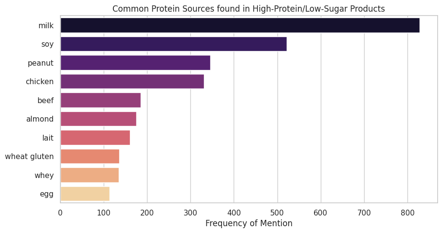

```python
# visual representation
plt.figure(figsize=(10, 5))
top_data = sorting_list[:10]
frequencies = [item[0] for item in top_data]
sources = [item[1] for item in top_data]

sns.barplot(x=frequencies, y=sources, hue=sources, palette='magma', legend=False)
plt.title('Common Protein Sources found in High-Protein/Low-Sugar Products')
plt.xlabel('Frequency of Mention')
plt.show()
```

## **6. The "Candidate's Choice" Challenge**

**Why I added this:**

I chose this because Sugar vs. Protein shows one dimension of health but the Nutriscore grade captures the full nutritional picture i.e sugar, fat, salt, fiber, and protein etc combined into one A to E score. Therefore, category full of D and E grades represents a larger Blue Ocean opportunity for disruption.

```python
# only rows with a valid nutriscore grade
nutriscore_data = food_data[food_data['nutriscore_grade'].isin(['a', 'b', 'c', 'd', 'e'])].copy()

# standardize grades for display
nutriscore_data['nutriscore_grade'] = nutriscore_data['nutriscore_grade'].str.upper()

# counting only products per category per grade
grade_counts = nutriscore_data.groupby(['primary_category', 'nutriscore_grade']).size().reset_index(name='product_count')

# filtering for categories with significant data (Total > 50 graded products)
category_totals = grade_counts.groupby('primary_category')['product_count'].sum()
significant_categories = category_totals[category_totals > 50].index
grade_counts = grade_counts[grade_counts['primary_category'].isin(significant_categories)]
```

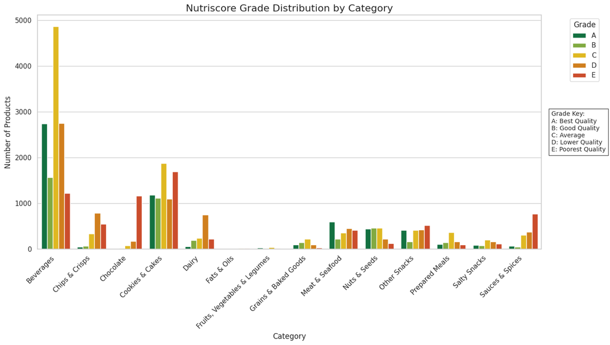

```python
# grouped bar chart using Matplotlib/Seaborn
import matplotlib.pyplot as plt
import seaborn as sns

# Set default style for consistency
sns.set_theme(style='whitegrid')

# Create a figure and axes
plt.figure(figsize=(14, 8))

# Plot the grouped bar chart
sns.barplot(
    data=grade_counts,
    x='primary_category',
    y='product_count',
    hue='nutriscore_grade',
    palette={'A': '#038141', 'B': '#85BB2F', 'C': '#FECB02', 'D': '#EE8100', 'E': '#E63E11'},
    order=grade_counts['primary_category'].unique() # Maintain category order
)

plt.title('Nutriscore Grade Distribution by Category', fontsize=16)
plt.xlabel('Category', fontsize=12)
plt.ylabel('Number of Products', fontsize=12)

# Add legend for Nutriscore Grades
plt.legend(title='Grade', bbox_to_anchor=(1.05, 1), loc='upper left')

# Add significance text as an annotation
significance_text = (
    "Grade Key:\n"
    "A: Best Quality\n"
    "B: Good Quality\n"
    "C: Average\n"
    "D: Lower Quality\n"
    "E: Poorest Quality"
)
plt.text(1.02, 0.5, significance_text, transform=plt.gca().transAxes, fontsize=10, verticalalignment='center', bbox=dict(facecolor='white', alpha=0.7, edgecolor='black'))

plt.xticks(rotation=45, ha='right') # Rotate x-axis labels for readability
plt.tight_layout() # Adjust layout to prevent labels from being cut off
plt.show()
```

```python
#  the percentage of unhealthy (D/E) grades for ALL categories
total_per_category = nutriscore_data.groupby('primary_category').size().reset_index(name='total')
bad_per_category = nutriscore_data[nutriscore_data['nutriscore_grade'].isin(['D', 'E'])].groupby('primary_category').size().reset_index(name='bad_count')

full_health_summary = total_per_category.merge(bad_per_category, on='primary_category', how='left').fillna(0)
full_health_summary['pct_unhealthy'] = (full_health_summary['bad_count'] / full_health_summary['total'] * 100).round(1)

#srting by the highest percentage of unhealthy products to highlight opportunity areas
full_health_summary = full_health_summary.sort_values('pct_unhealthy', ascending=False)

full_health_summary[['primary_category', 'total', 'pct_unhealthy']]
```

|  | primary_category | total | pct_unhealthy |
| --- | --- | --- | --- |
| 4 | Chocolate | 1421 | 93.4 |
| 3 | Chips & Crisps | 1763 | 75.4 |
| 15 | Sauces & Spices | 1553 | 73.3 |
| 2 | Candies & Sweets | 11 | 72.7 |
| 7 | Fats & Oils | 51 | 68.6 |
| 6 | Dairy | 1449 | 66.8 |
| 12 | Other Snacks | 1912 | 48.8 |
| 0 | Bars & Granola | 17 | 47.1 |
| 14 | Salty Snacks | 631 | 43.7 |
| 10 | Meat & Seafood | 2018 | 42.5 |
| 5 | Cookies & Cakes | 6940 | 40.0 |
| 1 | Beverages | 13131 | 30.2 |
| 13 | Prepared Meals | 851 | 29.4 |
| 8 | Fruits, Vegetables & Legumes | 94 | 24.5 |
| 11 | Nuts & Seeds | 1695 | 20.2 |
| 9 | Grains & Baked Goods | 563 | 19.7 |

```python
!jupyter nbconvert --to html /content/AmaliTech_Capstone_Project.ipynb
```

```
[NbConvertApp] Converting notebook /content/AmaliTech_Capstone_Project.ipynb to html
[NbConvertApp] WARNING | Alternative text is missing on 4 image(s).
[NbConvertApp] Writing 1114064 bytes to /content/AmaliTech_Capstone_Project.html
```